# Biostat 203B Homework 4

Due Mar 19 @ 11:59PM

Jiaheng Cai

Load database libraries and the tidyverse frontend:

```r
library(tidyverse)
library(lubridate)
library(miceRanger)
library(caret)
library(randomForest)
library(keras)
library(glmnet)
library(InformationValue)
```

## Q1. Missing data

Through the Shiny app developed in HW3, we observe abundant missing values in the MIMIC-IV ICU cohort we created. In this question, we use multiple imputation to obtain a data set without missing values.

0. Read following tutorials on the R package miceRanger for imputation: https://github.com/farrellday/miceRanger, https://cran.r-project.org/web/packages/miceRanger/vignettes/miceAlgorithm.html.

   A more thorough book treatment of the practical imputation strategies is the book [*Flexible Imputation of Missing Data*](https://stefvanbuuren.name/fimd/) by Stef van Buuren.
1. Explain the jargon MCAR, MAR, and MNAR.

MCAR (Missing complete at random): the probability of being missing is the same for all cases, we say the data is MCAR. MCAR implies that causes of missing data are unrelated to the data.

MAR (Missing at random): the probability of being missing is the same only within groups defined by observed data.

MNAR (Missing not at random): Not MCAR nor MAR. The probability of being missing varies for reasons that are unknown to us.

2. Explain in a couple of sentences how the Multiple Imputation by Chained Equations (MICE) work.

First, the algorithm will find a variable B which has strong correlation with the variable with missing data A, also another variable C. Regress A on B and obtain R^2. Randomly fill the data in the table, the R^2 will change since the fill in data are totally random. After that, use random forest to predict A by B and C. After, use A and C to predict B. Do this process repeatedly after the new R^2 is approaching the original R^2.

3. Perform a data quality check of the ICU stays data. Discard variables with substantial missingness, say >5000 `NA`s. Replace apparent data entry errors by `NA`s.

```r
icu_cohort_tib =
  readRDS('/home/odamadafaka/biostat-203b-2021-winter/hw4/icu_cohort.rds') %>%
  as_tibble() %>%
  subset(select = -c(stay_id.x))

icu_cohort_tib = subset(icu_cohort_tib, select = -c(deathtime, edregtime,
                                                    edouttime, dod, lactate, arterial_blood_pressure_systolic, arterial_blood_pressure_mean))

#remove false temp
icu_cohort_tib$temperature_fahrenheit[
  icu_cohort_tib$temperature_fahrenheit <= 95] = NA

#remove false res_rate
Q <- quantile(icu_cohort_tib$respiratory_rate, probs = c(.25, .75), na.rm = TRUE)
iqr <- IQR(icu_cohort_tib$respiratory_rate, na.rm = TRUE)
up <-  Q[2] + 1.5 * iqr # Upper Range
low <- Q[1] - 1.5 * iqr # Lower Range
icu_cohort_tib$respiratory_rate[icu_cohort_tib$respiratory_rate <= low |
                                  icu_cohort_tib$respiratory_rate >= up] = NA

#remove false nibpm
Q <- quantile(icu_cohort_tib$non_invasive_blood_pressure_mean, probs = c(.25, .75),
              na.rm = TRUE)
iqr <- IQR(icu_cohort_tib$non_invasive_blood_pressure_mean, na.rm = TRUE)
up <-  Q[2] + 1.5 * iqr # Upper Range
low <- Q[1] - 1.5 * iqr # Lower Range
icu_cohort_tib$non_invasive_blood_pressure_mean[
  icu_cohort_tib$non_invasive_blood_pressure_mean <= low |
    icu_cohort_tib$non_invasive_blood_pressure_mean >= up] = NA

#remove false nibps
Q <- quantile(icu_cohort_tib$non_invasive_blood_pressure_systolic, probs =
                c(.25, .75), na.rm = TRUE)
iqr <- IQR(icu_cohort_tib$non_invasive_blood_pressure_systolic, na.rm = TRUE)
up <-  Q[2] + 1.5 * iqr # Upper Range
low <- Q[1] - 1.5 * iqr # Lower Range
icu_cohort_tib$non_invasive_blood_pressure_systolic[
  icu_cohort_tib$non_invasive_blood_pressure_systolic <= low |
    icu_cohort_tib$non_invasive_blood_pressure_systolic >= up] = NA

#remove false heart rate
Q <- quantile(icu_cohort_tib$heart_rate, probs=c(.25, .75), na.rm = TRUE)
iqr <- IQR(icu_cohort_tib$heart_rate, na.rm = TRUE)
up <-  Q[2] + 1.5 * iqr # Upper Range
low <- Q[1] - 1.5 * iqr # Lower Range
icu_cohort_tib$heart_rate[icu_cohort_tib$heart_rate <= low |
                            icu_cohort_tib$heart_rate >= up] = NA

#remove false wbc
Q <- quantile(icu_cohort_tib$wbc, probs = c(.25, .75), na.rm = TRUE)
iqr <- IQR(icu_cohort_tib$wbc, na.rm = TRUE)
up <-  Q[2] + 1.5 * iqr # Upper Range
low <- Q[1] - 1.5 * iqr # Lower Range
icu_cohort_tib$wbc[icu_cohort_tib$wbc <= low | icu_cohort_tib$wbc >= up] = NA

#remove false hematocrit
Q <- quantile(icu_cohort_tib$hematocrit, probs=c(.25, .75), na.rm = TRUE)
iqr <- IQR(icu_cohort_tib$hematocrit, na.rm = TRUE)
up <-  Q[2] + 1.5 * iqr # Upper Range
low <- Q[1] - 1.5 * iqr # Lower Range
icu_cohort_tib$hematocrit[icu_cohort_tib$hematocrit <= low |
                            icu_cohort_tib$hematocrit >= up] = NA

#remove false hematocrit
Q <- quantile(icu_cohort_tib$hematocrit, probs=c(.25, .75), na.rm = TRUE)
iqr <- IQR(icu_cohort_tib$hematocrit, na.rm = TRUE)
up <-  Q[2] + 1.5 * iqr # Upper Range
low <- Q[1] - 1.5 * iqr # Lower Range
icu_cohort_tib$hematocrit[icu_cohort_tib$hematocrit <= low |
                            icu_cohort_tib$hematocrit >= up] = NA

#remove false sodium
Q <- quantile(icu_cohort_tib$sodium, probs=c(.25, .75), na.rm = TRUE)
iqr <- IQR(icu_cohort_tib$sodium, na.rm = TRUE)
up <-  Q[2] + 1.5 * iqr # Upper Range
low <- Q[1] - 1.5 * iqr # Lower Range
icu_cohort_tib$sodium[icu_cohort_tib$sodium <= low |
                        icu_cohort_tib$sodium >= up] = NA

#remove false potassium
Q <- quantile(icu_cohort_tib$potassium, probs=c(.25, .75), na.rm = TRUE)
iqr <- IQR(icu_cohort_tib$potassium, na.rm = TRUE)
up <-  Q[2] + 1.5 * iqr # Upper Range
low <- Q[1] - 1.5 * iqr # Lower Range
icu_cohort_tib$potassium[icu_cohort_tib$potassium <= low |
                           icu_cohort_tib$potassium >= up]=NA

#remove false magenesium
Q <- quantile(icu_cohort_tib$magnesium, probs=c(.25, .75), na.rm = TRUE)
iqr <- IQR(icu_cohort_tib$magnesium, na.rm = TRUE)
up <-  Q[2] + 1.5 * iqr # Upper Range
low <- Q[1] - 1.5 * iqr # Lower Range
icu_cohort_tib$magnesium[icu_cohort_tib$magnesium <= low |
                           icu_cohort_tib$magnesium >= up]=NA

#remove false glucose
Q <- quantile(icu_cohort_tib$glucose, probs=c(.25, .75), na.rm = TRUE)
iqr <- IQR(icu_cohort_tib$glucose, na.rm = TRUE)
up <-  Q[2] + 1.5 * iqr # Upper Range
low <- Q[1] - 1.5*iqr # Lower Range
icu_cohort_tib$glucose[icu_cohort_tib$glucose <= low |
                         icu_cohort_tib$glucose >= up]=NA

#remove false cretinine
Q <- quantile(icu_cohort_tib$creatinine, probs=c(.25, .75), na.rm = TRUE)
iqr <- IQR(icu_cohort_tib$creatinine, na.rm = TRUE)
up <-  Q[2] + 1.5 * iqr # Upper Range
low <- Q[1] - 1.5 * iqr # Lower Range
icu_cohort_tib$creatinine[icu_cohort_tib$creatinine <= low |
                            icu_cohort_tib$creatinine >= up]=NA

#remove false chloride
Q <- quantile(icu_cohort_tib$chloride, probs=c(.25, .75), na.rm = TRUE)
iqr <- IQR(icu_cohort_tib$chloride, na.rm = TRUE)
up <-  Q[2] + 1.5 * iqr # Upper Range
low <- Q[1] - 1.5*iqr # Lower Range
icu_cohort_tib$chloride[icu_cohort_tib$chloride <= low |
                          icu_cohort_tib$chloride >= up]=NA

#remove false calcium
Q <- quantile(icu_cohort_tib$calcium, probs=c(.25, .75), na.rm = TRUE)
iqr <- IQR(icu_cohort_tib$calcium, na.rm = TRUE)
up <-  Q[2] + 1.5 * iqr # Upper Range
low <- Q[1] - 1.5 * iqr # Lower Range
icu_cohort_tib$calcium[icu_cohort_tib$calcium <= low |
                         icu_cohort_tib$calcium >= up] = NA

#remove false bicarbonate
Q <- quantile(icu_cohort_tib$bicarbonate, probs=c(.25, .75), na.rm = TRUE)
iqr <- IQR(icu_cohort_tib$bicarbonate, na.rm = TRUE)
up <-  Q[2] + 1.5 * iqr # Upper Range
low <- Q[1] - 1.5 * iqr # Lower Range
icu_cohort_tib$bicarbonate[icu_cohort_tib$bicarbonate <= low |
                             icu_cohort_tib$bicarbonate >= up] = NA

icu_cohort_tib = subset(icu_cohort_tib, select = -c(creatinine))
summary(icu_cohort_tib)
```

```
##    subject_id          hadm_id         first_careunit     last_careunit
##  Min.   :10000032   Min.   :20000094   Length:50048       Length:50048
##  1st Qu.:12485686   1st Qu.:22465026   Class :character   Class :character
##  Median :14997274   Median :24937458   Mode  :character   Mode  :character
##  Mean   :14993100   Mean   :24967411
##  3rd Qu.:17501993   3rd Qu.:27473278
##  Max.   :19999987   Max.   :29999828
##
##      intime                       outtime
##  Min.   :2110-01-11 10:16:06   Min.   :2110-01-12 17:17:47
##  1st Qu.:2132-11-28 06:37:19   1st Qu.:2132-12-01 18:19:05
##  Median :2152-10-31 00:27:19   Median :2152-11-04 02:36:33
##  Mean   :2152-11-21 02:01:28   Mean   :2152-11-24 20:47:42
##  3rd Qu.:2172-11-24 22:56:23   3rd Qu.:2172-11-27 18:26:36
##  Max.   :2210-06-27 14:39:30   Max.   :2210-06-29 22:23:43
##
##       los              admittime
##  Min.   :  0.03469   Min.   :2110-01-11 10:14:00
##  1st Qu.:  1.11751   1st Qu.:2132-11-27 12:33:00
##  Median :  1.99117   Median :2152-10-29 18:23:30
##  Mean   :  3.78210   Mean   :2152-11-20 01:15:55
##  3rd Qu.:  4.01163   3rd Qu.:2172-11-24 07:18:45
##  Max.   :222.88872   Max.   :2210-06-26 16:00:00
##
##    dischtime                   admission_type     admission_location
##  Min.   :2110-01-15 17:31:00   Length:50048       Length:50048
##  1st Qu.:2132-12-09 08:11:30   Class :character   Class :character
##  Median :2152-11-07 20:04:00   Mode  :character   Mode  :character
##  Mean   :2152-11-29 10:12:47
##  3rd Qu.:2172-12-01 22:11:15
##  Max.   :2210-06-30 17:30:00
##
##  discharge_location  insurance           language         marital_status
##  Length:50048       Length:50048       Length:50048       Length:50048
##  Class :character   Class :character   Class :character   Class :character
##  Mode  :character   Mode  :character   Mode  :character   Mode  :character
##
##
##
##
```

[output cut: 41 more lines]

```
##  Min.   : 34.00                   Min.   : 5.00    Min.   : 95.10
##  1st Qu.: 69.00                   1st Qu.:15.00    1st Qu.: 97.60
##  Median : 80.00                   Median :18.00    Median : 98.20
##  Mean   : 81.18                   Mean   :18.19    Mean   : 98.22
##  3rd Qu.: 92.00                   3rd Qu.:21.00    3rd Qu.: 98.70
##  Max.   :128.00                   Max.   :32.00    Max.   :106.00
##  NA's   :2059                     NA's   :2226     NA's   :2249
##      de30
##  Length:50048
##  Class :character
##  Mode  :character
##
##
##
##
```

4. Impute missing values by `miceRanger` (request $m=3$ datasets). This step is very computational intensive. Make sure to save the imputation results as a file.

```r
seqTime <- system.time(
  miceObj <- miceRanger(icu_cohort_tib, m=3, returnModels = TRUE, verbose=FALSE,
                        max.depth = 10))
dataList <- completeData(miceObj)
head(dataList[[1]])
```

```
##    subject_id  hadm_id                                   first_careunit
## 1:   10000032 29079034               Medical Intensive Care Unit (MICU)
## 2:   10000980 26913865               Medical Intensive Care Unit (MICU)
## 3:   10001217 24597018              Surgical Intensive Care Unit (SICU)
## 4:   10001725 25563031 Medical/Surgical Intensive Care Unit (MICU/SICU)
## 5:   10001884 26184834               Medical Intensive Care Unit (MICU)
## 6:   10002013 23581541     Cardiac Vascular Intensive Care Unit (CVICU)
##                                       last_careunit              intime
## 1:               Medical Intensive Care Unit (MICU) 2180-07-23 14:00:00
## 2:               Medical Intensive Care Unit (MICU) 2189-06-27 08:42:00
## 3:              Surgical Intensive Care Unit (SICU) 2157-11-20 19:18:02
## 4: Medical/Surgical Intensive Care Unit (MICU/SICU) 2110-04-11 15:52:22
## 5:               Medical Intensive Care Unit (MICU) 2131-01-11 04:20:05
## 6:     Cardiac Vascular Intensive Care Unit (CVICU) 2160-05-18 10:00:53
##                outtime       los           admittime           dischtime
```

[output cut: 55 more lines]

5. Make imputation diagnostic plots and explain what they mean.

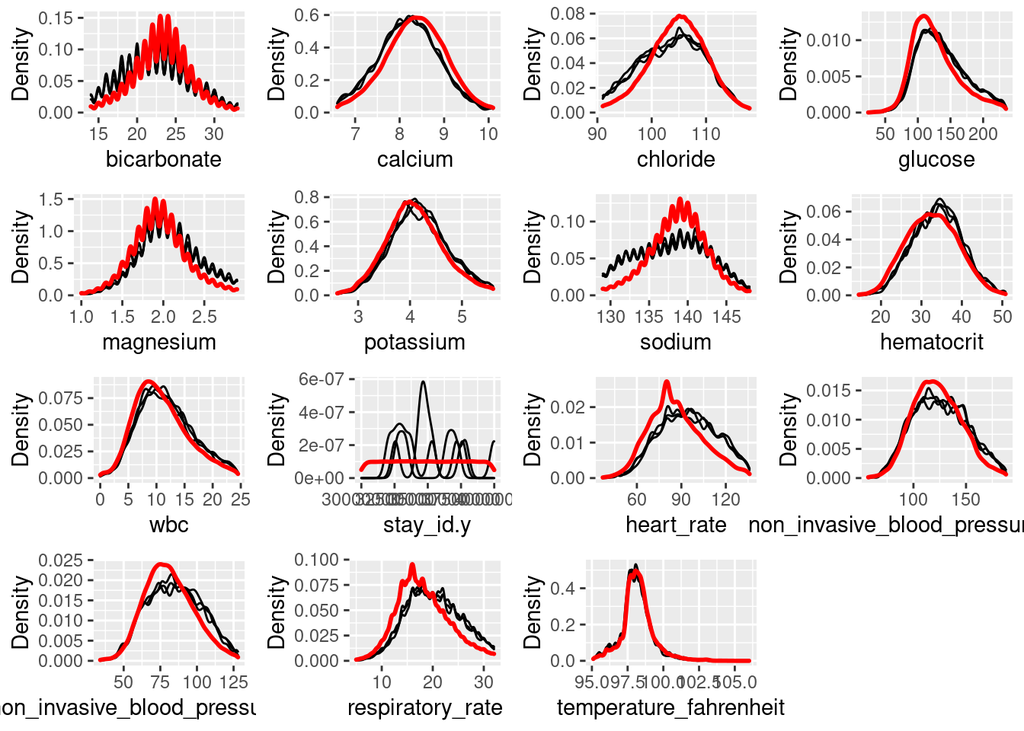

```r
plotDistributions(miceObj,vars='allNumeric')
```

This density plot compares the original dataset and the imputed dataset. If the original numeric data plot is not matching up with the imputed value, it suggests that the data is not missing at completely random.

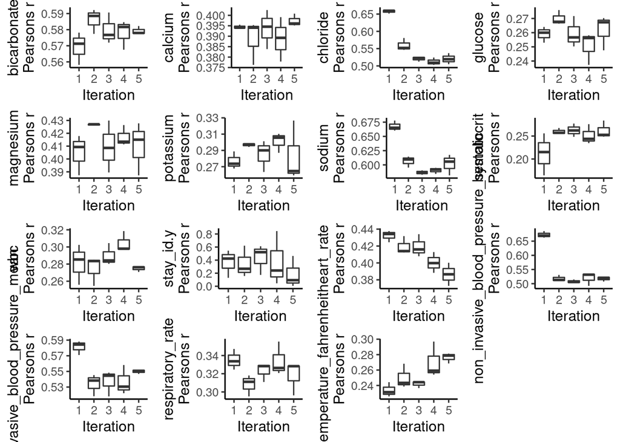

```r
plotCorrelations(miceObj,vars='allNumeric')
```

The boxplot displays the Pearson’s correlation coefficient over iteration. It’s used to determine the convergence over iterations.

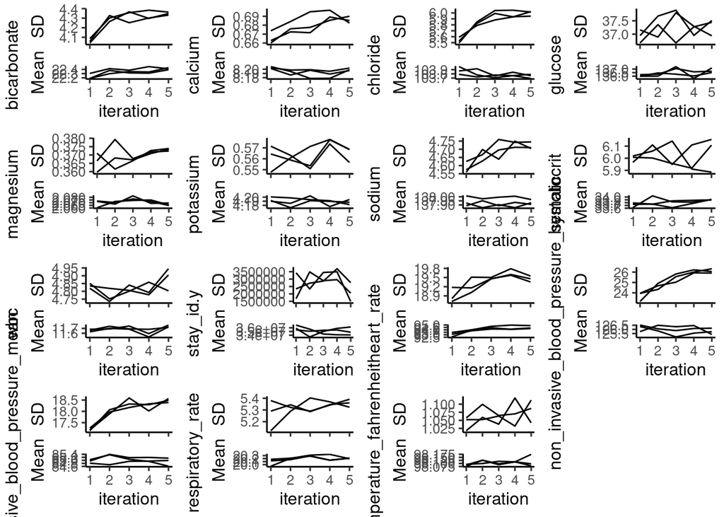

```r
plotVarConvergence(miceObj,vars='allNumeric')
```

This plot is used to see the convergence of the imputation. Variables with divergent line spread may need more iteration. (due to the computational power, I will not do more iterations. )

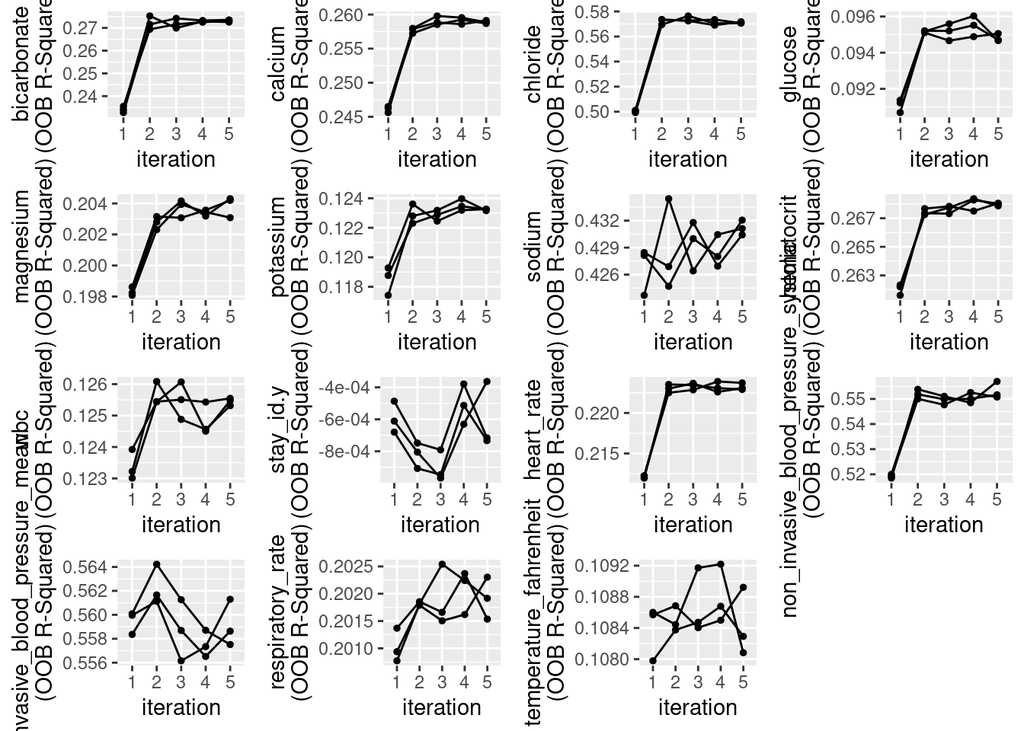

```r
plotModelError(miceObj,vars='allNumeric')
```

This plot also gives the convergence rate of each variable.

6. Obtain a complete data set by averaging the 3 imputed data sets.

```r
data = as.data.frame(data.matrix(dataList$Dataset_1) +
                       data.matrix(dataList$Dataset_2) +
                       data.matrix(dataList$Dataset_3)) / 3
# saveRDS(data,str_c('/home/odamadafaka/biostat-203b-2021-winter/hw4/data.rds'))
```

## Q2. Predicting 30-day mortality

Develop at least two analytic approaches for predicting the 30-day mortality of patients admitted to ICU using demographic information (gender, age, marital status, ethnicity), first lab measurements during ICU stay, and first vital measurements during ICU stay. For example, you can use (1) logistic regression (`glm()` function), (2) logistic regression with lasso penalty (glmnet package), (3) random forest (randomForest package), or (4) neural network.

1. Partition data into 80% training set and 20% test set. Stratify partitioning according the 30-day mortality status.

```r
data = read_rds('data.rds')
train.index <- createDataPartition(data$de30, p = .8, list = FALSE)
train <- data[ train.index,]
test  <- data[-train.index,]
```

2. Train the models using the training set.

```r
y_train = as.matrix(train$de30)
x_train = as.matrix(cbind(train$gender, train$anchor_age, train$marital_status,
                          train$ethnicity, train$potassium, train$sodium,
                          train$chloride, train$bicarbonate, train$hematocrit,
                          train$wbc, train$glucose, train$magnesium, train$calcium,
                        train$heart_rate, train$non_invasive_blood_pressure_mean,
                        train$non_invasive_blood_pressure_systolic,
                        train$temperature_fahrenheit,train$respiratory_rate))
y_test = as.matrix(test$de30)
x_test = as.matrix(cbind(test$gender, test$anchor_age, test$marital_status,
                          test$ethnicity, test$potassium, test$sodium,
                          test$chloride, test$bicarbonate, test$hematocrit,
                          test$wbc, test$glucose, test$magnesium, test$calcium,
                        test$heart_rate, test$non_invasive_blood_pressure_mean,
                        test$non_invasive_blood_pressure_systolic,
                        test$temperature_fahrenheit,test$respiratory_rate))
y_train[y_train == 2] = 0
y_test[y_test == 2] = 0
```

Log:

```r
log = glm(y_train ~ anchor_age +
                     potassium + sodium + chloride + bicarbonate + hematocrit +
                     wbc + glucose + magnesium +
                     calcium+heart_rate
                      +
                     non_invasive_blood_pressure_systolic +
                     temperature_fahrenheit+respiratory_rate, data = train,
          family = "binomial")
summary(log)
```

```
##
## Call:
## glm(formula = y_train ~ anchor_age + potassium + sodium + chloride +
##     bicarbonate + hematocrit + wbc + glucose + magnesium + calcium +
##     heart_rate + non_invasive_blood_pressure_systolic + temperature_fahrenheit +
##     respiratory_rate, family = "binomial", data = train)
##
## Deviance Residuals:
##     Min       1Q   Median       3Q      Max
## -3.3680   0.2366   0.3425   0.4755   2.0800
##
## Coefficients:
##                                        Estimate Std. Error z value Pr(>|z|)
## (Intercept)                          -4.3483611  1.7437259  -2.494 0.012641 *
## anchor_age                           -0.0283361  0.0011598 -24.431  < 2e-16 ***
## potassium                            -0.1041859  0.0315545  -3.302 0.000961 ***
## sodium                               -0.1136373  0.0063131 -18.000  < 2e-16 ***
## chloride                              0.1114371  0.0047251  23.584  < 2e-16 ***
## bicarbonate                           0.1614280  0.0054274  29.743  < 2e-16 ***
## hematocrit                            0.0084866  0.0029432   2.884 0.003933 **
## wbc                                  -0.0254432  0.0036482  -6.974 3.07e-12 ***
## glucose                              -0.0041472  0.0004765  -8.704  < 2e-16 ***
## magnesium                            -0.2616813  0.0522613  -5.007 5.52e-07 ***
## calcium                               0.2969015  0.0294653  10.076  < 2e-16 ***
## heart_rate                           -0.0107312  0.0010300 -10.419  < 2e-16 ***
## non_invasive_blood_pressure_systolic  0.0091792  0.0007862  11.675  < 2e-16 ***
## temperature_fahrenheit                0.0910483  0.0163659   5.563 2.65e-08 ***
## respiratory_rate                     -0.0608817  0.0035846 -16.984  < 2e-16 ***
## ---
## Signif. codes:  0 '***' 0.001 '**' 0.01 '*' 0.05 '.' 0.1 ' ' 1
##
## (Dispersion parameter for binomial family taken to be 1)
##
##     Null deviance: 26651  on 40038  degrees of freedom
## Residual deviance: 23081  on 40024  degrees of freedom
## AIC: 23111
##
## Number of Fisher Scoring iterations: 5
```

log-lasso:

```r
lasso = glmnet(x_train, y_train, family="binomial", alpha=1)
```

random forest:

```r
rf <- randomForest(as.factor(y_train) ~  gender + anchor_age + marital_status + ethnicity +
                     potassium + sodium + chloride + bicarbonate + hematocrit +
                     wbc + glucose + magnesium +
                     calcium+heart_rate +
                     non_invasive_blood_pressure_mean +
                     non_invasive_blood_pressure_systolic +
                     temperature_fahrenheit+respiratory_rate, data = train)
```

3. Compare model prediction performance on the test set. log:

```r
predictionlog = predict(log, test, type="response")
optCutOff = optimalCutoff(y_test, predictionlog)[1]
predicted.classes = ifelse(predictionlog > optCutOff, "1", "0")
confusionMatrix((as.matrix(predicted.classes)),
                (as.matrix(y_test)))
```

```
##    0    1
## 0 61  976
## 1 45 8927
```

log-lasso: (for some reason, i kept getting a large matrix as result (10009*55))

```r
predictionlogla = predict.glmnet(lasso, x_test)
```

Random Forest:

```r
rf$confusion[, 'class.error']
```

```
##           1           2
## 0.002646756 0.952243126
```

```r
predictionrf = predict(rf, test)
confusionMatrix((as.matrix(predictionrf)), (as.matrix(y_test)))
```

```
##      1  2
## 0  983 54
## 1 8949 23
```

Note: keras kept giving error message about miniconda, might be a problem from compatibility.